# Ecological effects of submarine groundwater discharge and neighborhood interactions on common coral species, Porites rus

Jamie Kerlin

2022-05-31

## Purpose of this RMarkdown

This RMarkdown is the analysis for “Ecological effects of submarine groundwater discharge and neighborhood interactions on common coral species, Porites rus”, by J.R. Kerlin, D.M. Barnas, and N.J. Silbiger.

## Load libraries

```r
library(tidyverse)
library(here)
library(purrr)
library(broom)
library(performance)
library(factoextra)
library(car)
library(marginaleffects)
library(sjPlot)
library(margins)
library(ggtext)
library(lme4)
library(lmerTest)
library(broom.mixed)
library(ggpubr)
library(vtable)
library(lmtest)
library(patchwork)
library(kableExtra)
library(ggcorrplot)
library(MuMIn)
```

## Notes on this analysis

12/2/2022: Currently, all outliers are still in this analysis: - 7h is outlier for CCcm2 - 7h is outlier for ED - 14m and 14h come up as outlier for R in boxplots but not models - At high ranges of pH, there are only conspecific treatments, can we compare these?

I have growth data and metabolism data ready from my experiment and water biogeochemistry data. 80 fragments were deployed. 72 fragments were recovered. 59 fragments did not have any competitors missing- these were used in the analysis.

There are 15 no competition treatments left.  
There are 13 dead skeletal competition treatments left. There are 16 conspecific treatments left.  
There are 15 heterospecific treatments left.

In this analysis, I am looking at 2 metabolism rates and 2 endosymbiont physiology values:  
- gross photosynthesis & respiration  
- endosymbiont density & chlorophyll a content

My experiment was deployed (8/3-8/17/2021). There seemed to be some outliers in the CT temp data, so I filtered out temps over 32C. 12S was somehow lost in the freezer, so no endosymbiont physio data for this fragment.

## Load data

```r
# Coral physiological response variable data (with all recovered fragments)

coral <- read_csv(here("Data",
                       "Coral",
                       "coral_response.csv")) %>%
  filter(Response_measurement != "NP") #not analyzing net photosynthesis

cc_cell <- read_csv(here("Data",
                         "Coral",
                         "cc_cell.csv"))

coral <- rbind(coral, cc_cell) %>%
  filter(Response_measurement != "CCcm2") %>%
  mutate(Response_measurement = if_else(Response_measurement == "CC_cell", "CCcm2", Response_measurement))

# Site biogeochemistry data

bgc <- read_csv(here("Data",
                     "Site",
                     "site_biogeochemistry_summstats.csv"))

# Here is information on the plate collection where I look at which fragments were missing
fragments <- read_csv(here("Data",
                           "Metadata",
                           "Coral",
                           "complete_treatments.csv"))

depth <- read_csv(here("Data",
                       "Site",
                       "adj_plate_depth.csv")) %>%
  filter(Location == "Varari" & CowTagID != "VSEEP") %>%
  mutate(CowTagID = as.numeric(gsub("V", "", CowTagID)))


#choosing colors for plots

colors <- c("#a45851", "#eba07e", "#b0cbe7", "#5d74a5")
```

## Data cleaning

I’ll clean up the data for which fragments were missing when I collected the plates.

This is removing all plates that were missing their center fragments (8 plates) and those that were missing any competitors (13 more plates).

9 of the 20 locations have all their treatments.  
14 of the 20 locations have at least 3/4 of their treatments.  
16 of the 20 locations have at least 2/4 of their treatments.  
4 of the 20 locations only have 1 of their treatments.

There are 15 no competition treatments left.  
There are 13 space competition treatments left (dead skeletal).  
There are 16 conspecific treatments left.  
There are 15 heterospecific treatments left.

```r
fragments1 <- fragments %>%
  select(FragmentID, Missing_comp, Missing_central) %>%
  filter(Missing_central == 0 & Missing_comp == 0)
```

I’ll combine the coral response variable dataset with the SGD biogeochemistry dataset + the “fragments” df. We need one in long format and one in wide format for the following analyses. From this, I have a total of 59 fragments that are being analyzed, compared to the 72 fragments I would have analyzed if I did not remove the fragments that were missing competitors.

```r
data_long <- left_join(coral, bgc) %>%
  right_join(fragments1)

data_wide <- data_long %>%
  select(!Predictor_scaled) %>%
  pivot_wider(names_from = Predictor_measurement,
              values_from = Predictor_value)
```

Biogeochem summ table

```r
biogeochem_table <- data_long %>%
  select(CowTagID, Predictor_measurement, Predictor_value) %>%
  unique() %>%
  separate(Predictor_measurement, into = c("Measurement", "Parameter")) %>%
  pivot_wider(names_from = "Measurement", values_from = "Predictor_value") %>%
  rename(Minimum = min, Mean = mean, Maximum = max, Range = range) %>%
  mutate(Parameter = case_when(Parameter == "Temperature" ~ "Temperature (°C)",
                            Parameter =="NN" ~ "Nitrate + Nitrite (µmol L-1)",
                            Parameter == "Phosphate" ~ "Phosphate (µmol L-1)",
                            Parameter == "Salinity" ~ "Salinity (psu)",
                            Parameter == "pH" ~ "pH"))

biogeochem_table_overall <- biogeochem_table %>%
  group_by(Parameter) %>%
  summarise(Minimum_min = round(min(Minimum), 2),
            Minimum_max = round(max(Minimum), 2),
            Mean_min = round(min(Mean), 2),
            Mean_max = round(max(Mean), 2),
            Maximum_min = round(min(Maximum), 2),
            Maximum_max = round(max(Maximum), 2),) %>%
  mutate(Range = round((Maximum_max - Minimum_min), 2)) %>%
  select(Parameter, Minimum_min, Mean_min, Maximum_min, Minimum_max, Mean_max, Maximum_max, Range) %>%
  kbl("html", col.names = c("Parameter",
                    "Minimum", "Mean", "Maximum",
                    "Minimum", "Mean", "Maximum", "Range")) %>%
  kable_classic_2(full_width = F, html_font = "Cambria", "striped") %>%
  column_spec(c(5, 6, 7), color = "white", background = "#a45851") %>%
  column_spec(c(2, 3, 4), color = "white", background = "#5d74a5") %>%
  add_header_above(c(" " = 1, "Low Range" = 3, "High Range" = 3, " " = 1))


biogeochem_table_overall
```

| Parameter | Low Range Minimum | Low Range Mean | Low Range Maximum | High Range Minimum | High Range Mean | High Range Maximum | Range |
| --- | --- | --- | --- | --- | --- | --- | --- |
| Nitrate + Nitrite (µmol L-1) | 0.23 | 0.35 | 0.47 | 0.57 | 0.72 | 1.34 | 1.11 |
| Phosphate (µmol L-1) | 0.18 | 0.20 | 0.21 | 0.22 | 0.24 | 0.31 | 0.13 |
| Salinity (psu) | 36.41 | 36.73 | 36.86 | 36.87 | 36.97 | 37.18 | 0.77 |
| Temperature (°C) | 25.99 | 27.18 | 28.43 | 26.61 | 27.53 | 29.11 | 3.12 |
| pH | 7.97 | 8.03 | 8.05 | 8.04 | 8.05 | 8.10 | 0.13 |

```r
# make each data frame and plot separately so can have different range scales

biogeochem_nn <- biogeochem_table %>%
  pivot_longer(cols = Minimum:Mean,
               names_to = "Type",
               values_to = "Value") %>%
  filter(grepl("Nitrate", Parameter)) %>%
  mutate(Value = round(Value, 2),
         Range = round(Range, 2))

biogeochem_pH <- biogeochem_table %>%
  pivot_longer(cols = Minimum:Mean,
               names_to = "Type",
               values_to = "Value") %>%
  filter(grepl("pH", Parameter)) %>%
  mutate(Value = round(Value, 2),
         Range = round(Range, 2))


biogeochem_salinity <- biogeochem_table %>%
  pivot_longer(cols = Minimum:Mean,
               names_to = "Type",
               values_to = "Value") %>%
  filter(grepl("Salinity", Parameter)) %>%
  mutate(Value = round(Value, 2),
         Range = round(Range, 2))


biogeochem_temp <- biogeochem_table %>%
  pivot_longer(cols = Minimum:Mean,
               names_to = "Type",
               values_to = "Value") %>%
  filter(grepl("Temperature", Parameter)) %>%
  mutate(Value = round(Value, 2),
         Range = round(Range, 2))


biogeochem_phos <- biogeochem_table %>%
  pivot_longer(cols = Minimum:Mean,
               names_to = "Type",
               values_to = "Value") %>%
  filter(grepl("Phosphate", Parameter))%>%
  mutate(Value = round(Value, 2),
         Range = round(Range, 2))


#plots

sal <- ggplot(biogeochem_salinity, mapping = aes(x = Type, y = Value)) +
geom_boxplot(outlier.shape = NA) +
  facet_wrap(~Parameter, scales = "free") +
  geom_jitter(aes(color = Range), width = 0.15) +
  scale_x_discrete(limits = c("Minimum", "Mean", "Maximum")) +
  theme_bw() +
  labs(x = "", y = "") +
  theme(axis.text = element_text(size = 12),
        strip.text = element_text(size = 12))

sal %>% ggsave(filename = here("Output", "Biogeochem_plots", "sal.png"),
              width  = 4, height = 4)


pH <- ggplot(biogeochem_pH, mapping = aes(x = Type, y = Value)) +
  geom_boxplot(outlier.shape = NA) +
  facet_wrap(~Parameter, scales = "free") +
  geom_jitter(aes(color = Range), width = 0.15) +
  scale_x_discrete(limits = c("Minimum", "Mean", "Maximum")) +
  theme_bw() +
  labs(x = "", y = "")+
  theme(axis.text = element_text(size = 12),
        strip.text = element_text(size = 12))

pH %>% ggsave(filename = here("Output", "Biogeochem_plots", "pH.png"),
              width  = 4, height = 4)


nn <- ggplot(biogeochem_nn, mapping = aes(x = Type, y = Value)) +
  geom_boxplot(outlier.shape = NA) +
  facet_wrap(~Parameter, scales = "free") +
  geom_jitter(aes(color = Range), width = 0.15) +
  scale_x_discrete(limits = c("Minimum", "Mean", "Maximum")) +
  theme_bw() +
  labs(x = "", y = "")+
  theme(axis.text = element_text(size = 12),
        strip.text = element_text(size = 12))

nn %>% ggsave(filename = here("Output", "Biogeochem_plots", "nn.png"),
              width  = 4, height = 4)



temp <- ggplot(biogeochem_temp, mapping = aes(x = Type, y = Value)) +
  geom_boxplot(outlier.shape = NA) +
  facet_wrap(~Parameter, scales = "free") +
  geom_jitter(aes(color = Range), width = 0.15) +
  scale_x_discrete(limits = c("Minimum", "Mean", "Maximum")) +
  theme_bw() +
  labs(x = "", y = "") +
  theme(axis.text = element_text(size = 12),
        strip.text = element_text(size = 12))

temp %>% ggsave(filename = here("Output", "Biogeochem_plots", "temp.png"),
              width  = 4, height = 4)


phos <- ggplot(biogeochem_phos, mapping = aes(x = Type, y = Value)) +
  geom_boxplot(outlier.shape = NA) +
  facet_wrap(~Parameter, scales = "free") +
  geom_jitter(aes(color = Range), width = 0.15) +
  scale_x_discrete(limits = c("Minimum", "Mean", "Maximum")) +
  theme_bw() +
  labs(x = "", y = "") +
  scale_color_continuous(breaks = c(0.02, 0.04, 0.06, 0.08, .10)) +
  theme(axis.text = element_text(size = 12),
        strip.text = element_text(size = 12))

phos %>% ggsave(filename = here("Output", "Biogeochem_plots", "phos.png"),
              width  = 4, height = 4)
```

Look for outliers

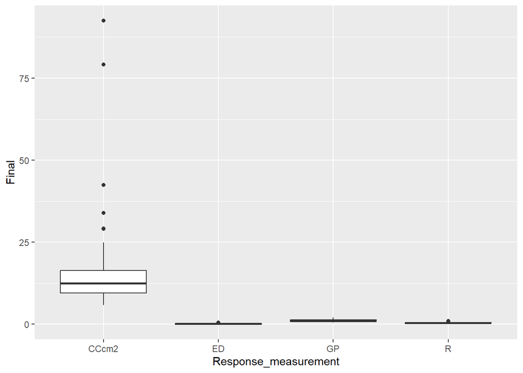

```r
ggplot(data_wide, mapping = aes(x = Response_measurement, y = Final)) +
  geom_boxplot()
```

```r
# 14m and 14h look like potential outliers in boxplot for R, but are not outliers in the model, so leaving in
# the outlier for ED and CC are the same (7h), could be fragment with high ED has more CC/cm2
```

Next, I’ll create separate dataframes for each response variable.

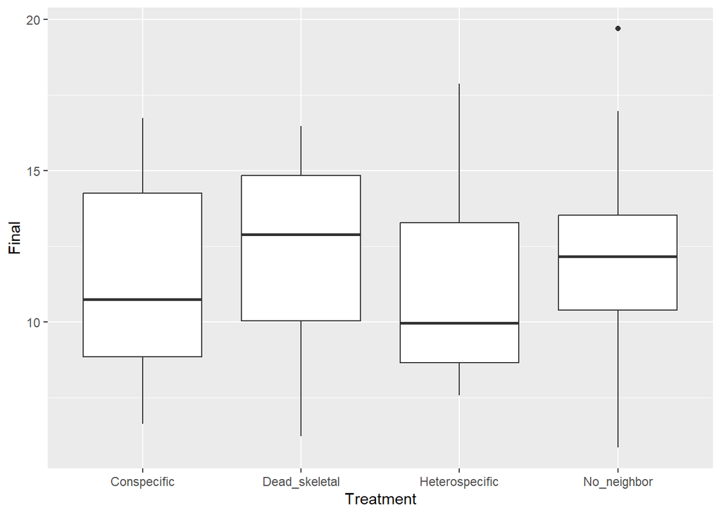

```r
# Dataframes with observations for all neighbor treatments

GP_plot <- data_wide %>%
  filter(Response_measurement == "GP")

R_plot <- data_wide %>%
  filter(Response_measurement == "R")

ED_plot <- data_wide %>%
  filter(Response_measurement == "ED")

CC_plot <- data_wide %>%
  filter(Response_measurement == "CCcm2") %>%
  filter(Final < 22 & Initial < 22)

# Dataframes with observations for only no neighbor treatment (wide format)

GP_plot_control <- GP_plot %>%
  filter(Treatment == "No_neighbor")

R_plot_control <- R_plot %>%
  filter(Treatment == "No_neighbor")

ED_plot_control <- ED_plot %>%
  filter(Treatment == "No_neighbor")

CC_plot_control <- CC_plot %>%
  filter(Treatment == "No_neighbor")

ggplot(CC_plot, mapping = aes(x = Treatment, y = Final)) +
  geom_boxplot()
```

```r
# Dataframes with observations for only no neighbor treatment (long format)

GP_long_control <- data_long %>%
  filter(Response_measurement == "GP") %>%
  filter(Treatment == "No_neighbor")

R_long_control <- data_long %>%
  filter(Response_measurement == "R") %>%
  filter(Treatment == "No_neighbor")

ED_long_control <- data_long %>%
  filter(Response_measurement == "ED") %>%
  filter(Treatment == "No_neighbor")

CC_long_control <- data_long %>%
  filter(Response_measurement == "CCcm2") %>%
  filter(Treatment == "No_neighbor",
         Final < 40)
```